# Network Analysis for Ecologists (NWAE01)

## 1.6 Network Properties

Now that we have an igraph representation of our network(s), we can calculate several of its properties.

### 1.6.1 Graph connectivity / Food web connectance

If we think of the network we just constructed as a food web, we can calculate the number of species and links (what we did previously on adjacency matrices) thus:

```r
# number of species
S <- vcount(network)

# number of interactions
L <- ecount(network)
```

The functions `vcount` and `ecount` from the igraph library let you count the number of nodes and links on a graph, respectively.

Having counted the number of species and links in our newly built food web, we can start calculating more interesting prorperties such as connectivity. In food webs connectivity can be quantified as the average number of interactions per species (L/S, i.e. the mean number of interactions species in the network have), and `Connectance` (L/S<sup>2</sup>, i.e. the fraction of links present in the network out of all possible links).

```r
# average number of interactions species
L.S <- L/S

# food web connectance
C <- L/S^2
```

In the case of the adjacency matrix (A) representation of a food web, we know that it contains all the links in our network represented by 1’s. Hence, the number of links in our network is simply sum(A). Similarly we have also learnt that the number of species (at least for a food web) equals the number of rows (or columns) in the matrix: nrow(A).

Hence, the connectance of our food web represented by matrix A is calculated as: sum(A)/(nrow(A)<sup>2</sup>). Try this on your network above and you should obtain the same quantity we now have in `C`. **HINT:** To obtain the adjacency matrix representation of an igraph object you can use the `as_adjacency_matrix` function.

For the Benguela network we can calculate connectivity properties:

```r
# Calculate connectance
connectance <- ecount(benguela.network) / vcount(benguela.network)^2

# Print connectance va
print(paste0('Connectance of Benguela network = ', round(connectance,2)))
```

```
## [1] "Connectance of Benguela network = 0.24"
```

```r
# Calculate number of links per species
links.per.species <- ecount(benguela.network) / vcount(benguela.network)
```

### 1.6.2 Connectance in bipartite networks

We have learnt how to calculate the connectance of ecological networks in general: it is simply the fraction of realised links out of the possible ones. Additionally, we have explored methods to quantify connectance in food webs based on the information extracted either from the adjacency matrix or the igraph representation of our networks.

We have also learnt that the way in which bipartite networks are represented in incidence matrices is fundamentally different from the way in which we represent food webs in adjacency matrices. Keeping that in mind, we need to find out ways of finding out what would be: 1.- the correct way of finding out the number of species in a bipartite network from our matrix representation; and 2.- the total possible number of links in a bipartite network (remember that links between species in the same group are ‘forbidden’).

Using the fish-anemone interaction network that we used previously, we can calculate the total number of possible links as the product of the number of species on one side (i.e. fish) times the number of species on the other side (i.e. anemone). This will give us the total number of links if every fish species would be found to interact with each anemone species. Connectance of this network is then simply the total number of links divided by this quantity.

```r
# Calculate conectance of anemoref
bipartite.connectance <- sum(anemonef) / (dim(anemonef)[1] * dim(anemonef)[2])
```

Igraph lets us manipulate bipartite networks in a similar way to unipartite ones. We can load the incidence matrix above using the following instruction:

```r
anemonef.network <- graph_from_incidence_matrix(anemonef, directed = TRUE, mode = 'in')
```

And calculate its connectance thus:

```r
# Calculate conectance of anemoref
bipartite.connectance <- ecount(anemonef.network) / (sum(V(anemonef.network)$type) * (vcount(anemonef.network) - sum(V(anemonef.network)$type)) )
```

As a fun exercise you can try and calculate the average number of links per species in this network!

Aside from the connectivity measures that we learnt in the previous section, more interesting properties can be calculated on ecological networks. In this chapter, we introduce some of these properties and how to calculate them.

### 1.6.3 Horizontal Diversity : Generality and Vulnerability

Ecological networks are all about species and their interactions. In food webs, these interactions represent consumer-resource relationships, so the set of relationships that a consumer has with its prey is considered the ‘breadth’ of its diet. This diet breadth is a measure of the generality of the consumer species and a mean generality index can be calculated across the network to have an idea of how generalist are species in the network on average. We can calculate generality on the matrix representation of our food webs using the following function:

```r
## Mean generality of species in the network
Generality <- function(M){
  return(sum(colSums(M))/sum((colSums(M)!=0)));
}
```

Similarly, we can obtain a measure of the average number of consumers that resources on our networks have (i.e. vulnerability) using the following function on our adjacency matrix:

```r
## Mean vulnerability of the species in the network
Vulnerability <- function(M){
  return(sum(rowSums(M))/sum((rowSums(M)!=0)));
}
```

To be able to compare these quantities across different networks, they are usually normalised by the average number of links per species (`L/S`).

If we are interested in these quantities at the species level, we simply count their prey or predator numbers or their `degree` in the network:

```r
## In-degree or number of prey of all species in the network
InDegree <- function(M){
  return(colSums(M));
}

## Out-degree or number of predators of all species in the network
OutDegree <- function(M){
  return(rowSums(M));
}
```

Even though these measures are useful to have an idea of the average diet breadth and number of consumers across species in our networks, in many occasions it is desirable to look at the deviation of these properties, since we can have within the same network generalist species such as this guy on the left… … alongside very specialist species, such as this guy on the right…

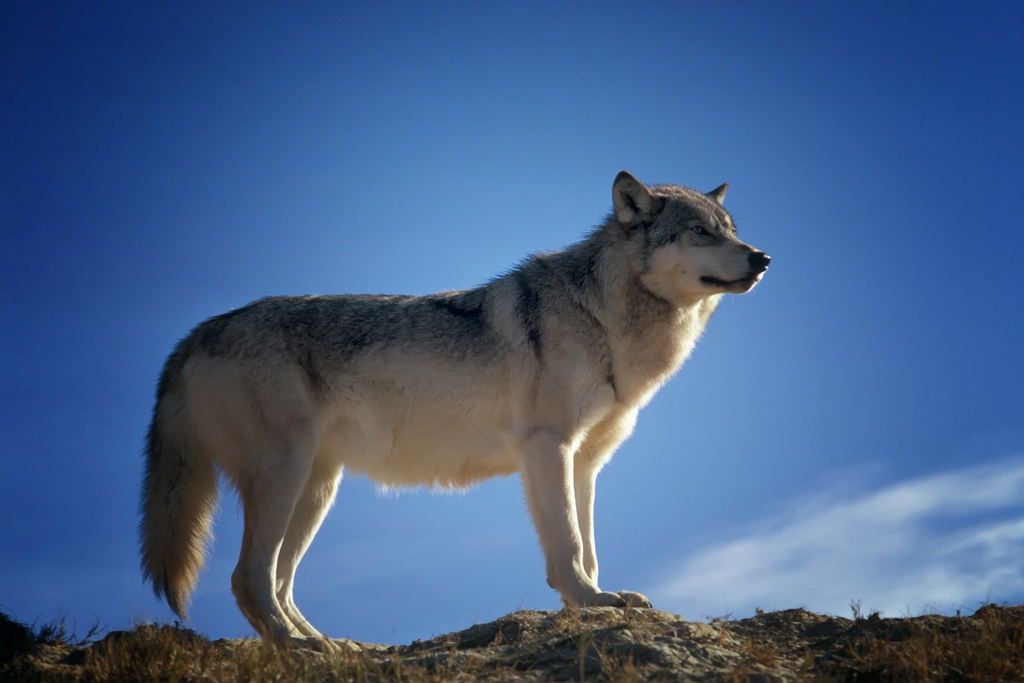

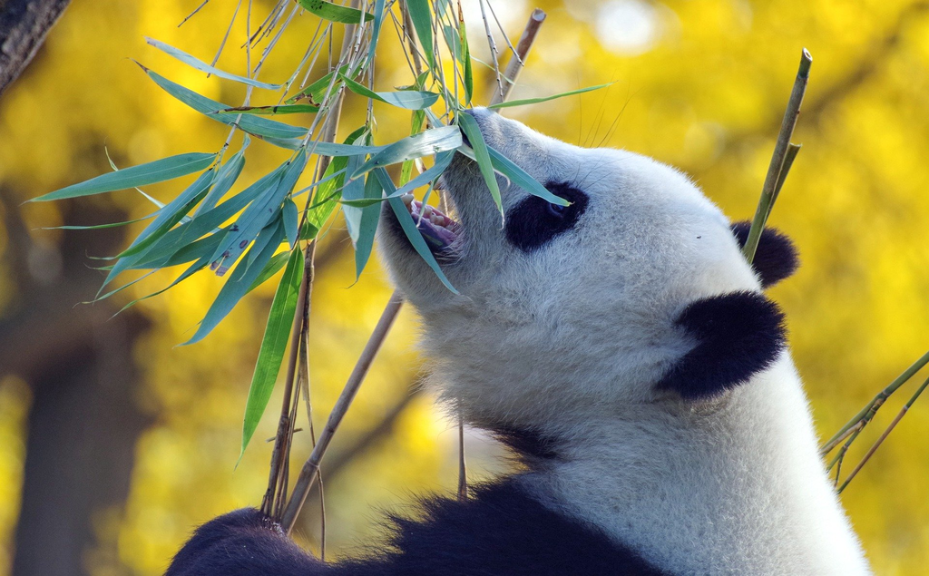

To assess variability in diet breadth and the degree of vulnerability of species in a food web, metrics such as the standard deviation of normalised generality and vulnerability are useful. These properties can be calculated using the following formulae:

*Generality*
$$G_i
= \frac{1}{L/S}\sum_{j=1}^{S}a_{ji}$$
*Vulnerability*
$$V_i
= \frac{1}{L/S}\sum_{j=1}^{S}a_{ij}$$

where a<sub>ij</sub> are the i,j values of the adjacency matrix `A` representing the food web.

Using R code they can be calculated thus:

```r
## Standard deviation of generality:
SDGenerality <- function(M){
  return(sd(colSums(M) / (sum(M)/dim(M)[1]) ));
}

## Standard deviation of vulnerability:
SDVulnerability <- function(M){
  return(sd(rowSums(M) / (sum(M)/dim(M)[1]) ));
}
```

### 1.6.4 Vertical Diversity : Fraction of Species Types

In food webs, we can categorise species according to the role the perform from an ecosystem functioning point of view. Basal resources are species at the base of food chains. They are in charge of converting organic and inorganic compounds into biomass such as, for example, plants or phytoplankton. It is interesting to know the fraction of species in food webs that belong to this category.

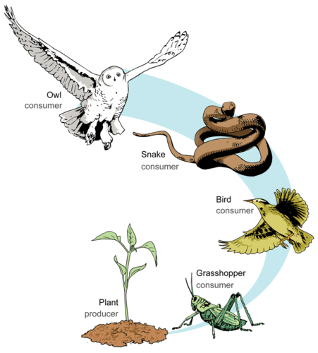

```r
## Fraction of basal species
FractionOfBasal <- function(M){
  M_temp <- M;
  diag(M_temp) <- 0;

  b_sps <- sum(which(InDegree(M_temp) == 0) %in% which(OutDegree(M_temp) >= 1));

  return(b_sps / dim(M)[1]);
}
```

Similarly, knowing the fraction of species belonging to intermediate and top consumer categories can give us information about the degree of predation pressure and top-down regulation expected in the network, and its corresponding community, being analysed.

```r
## Fraction of top predator species
FractionOfTop <- function(M){
  M_temp <- M;
  diag(M_temp) <- 0;

  t_sps <- sum(which(InDegree(M_temp) >= 1) %in% which(OutDegree(M_temp) == 0));

  return(t_sps / dim(M)[1]);
}
```

```r
## Fraction of intermediate consumer species
FractionOfIntermediate <- function(M){
  M_temp <- M;
  diag(M_temp) <- 0;

  i_sps <- sum(which(InDegree(M_temp) >= 1) %in% which(OutDegree(M_temp) >= 1));

  return(i_sps / dim(M)[1]);
}
```

For the Benguela food web we can obtain these properties using the functions defined above.

```r
gen <- Generality(benguela.AM)
vul <- Vulnerability(benguela.AM)
sdgen <- SDGenerality(benguela.AM)
sdvul <- SDVulnerability(benguela.AM)
B <- FractionOfBasal(benguela.AM)
I <- FractionOfIntermediate(benguela.AM)
T <- FractionOfTop(benguela.AM)
```

### 1.6.5 Vertical Complexity : Mean Food Chain Length

Food chains like those illustrated in the figure above are the exception rather than the norm in nature. Ecological communities are way more complex than this, such as the Benguela food web we saw before. You can imagine a real ecological community as a collection of interconnected food chains. One way to summarise this complexity is to calculate the average length of food chains in the network, i.e. the average number of links from basal resources to top predators or mean food chaing length.

To be able to quantify this, we need to visit all paths in our network running from each basal species to each top predator species. This is a computing intensive task that, for large networks, requires large computational resources (including long execution times). In graph theory and network topology, there is considerable research devoted into how to best count [average paths in networks](https://en.wikipedia.org/wiki/Average_path_length). If you are interested, this is a fascinating area of research and you can play with functions such as [distances](https://igraph.org/r/doc/distances.html) on igraph to find out more.

In food webs, the paths we are interested in are special because they all start in basal resources and they all stop at top predators. So, the way in which we should count those paths is a bit different than what functions such as `distances` do. Fortunately, there exist libraries for food web analysis that can help us calculate metrics and statistics particularly tailored for food webs. One such a package is [cheddar](http://quicklizard99.github.io/cheddar/). Cheddar let’s you calculate all of the food web properties we have seen so far and many more. We will take advantage of cheddar to calculate mean food chain length. This will also get you familiar with cheddar and you can explore many more functionalities offered by the package.

Calculating mean food chain length using cheddar:

```r
MeanFoodChainLength <- function(M){
  require(cheddar)
  M <- t(M)
  node <- 1:dim(M)[1];
  for(n in 1:length(node)){
    node[n] <- paste(node[n],'-');
  }

  pm <- matrix(M, ncol=dim(M)[2], dimnames=list(node, node), byrow=TRUE);

  # We need to convert our adjacency matrix into a Chedday community object.
  # For this, we yse PredationMatrixToLinks()
  community <- Community(nodes=data.frame(node=node), trophic.links=PredationMatrixToLinks(pm), properties=list(title='Community'));

  # We remove cannibalistic links to avoid entering an infinte loop when calculating path lengths
  community <- RemoveCannibalisticLinks(community, title='community');

  chain.stats <- TrophicChainsStats(community)
  ch_lens <- (chain.stats$chain.lengths + 1)

  return(sum(ch_lens)/length(ch_lens));
}

print(MeanFoodChainLength(benguela.AM))
```

```
## [1] 9.658458
```

### 1.6.6 Degree Distributions

Degree distributions constitute a convenient graphical representation of the probabilities of finding a node in a network possessing a certain number of links. This property is important because the shape of the degree distribution of complex networks has been linked to their robustness to random and targeted attacks to their nodes. In particular, networks with degree distributions that follow a *power law*, which are called scale free networks, are robust against random attacks due to the prevalence of nodes with a small number of links.

Even though the prevalence of truly scale free networks (in the sense of the degree distributions following exactly a power law) has been disputed, networks with degree distributions that display a ‘fat tail’ have been identified in many natural and technological systems from social networks to the internet. Ecological networks are not an exception. This suggests that common underlying principles might be involved in the formation of these networks.

Given its recognised importance and relevance for network persistence we might be interested in obtaining the degree distribution of our ecological networks.

To get the degree distribution of the Benguela network we can follow the instructions below. Since the degree distribution of [ecological networks has been suggested to generally follow a truncated power law](https://www.nature.com/articles/nature04927), we fit that curve to our data.

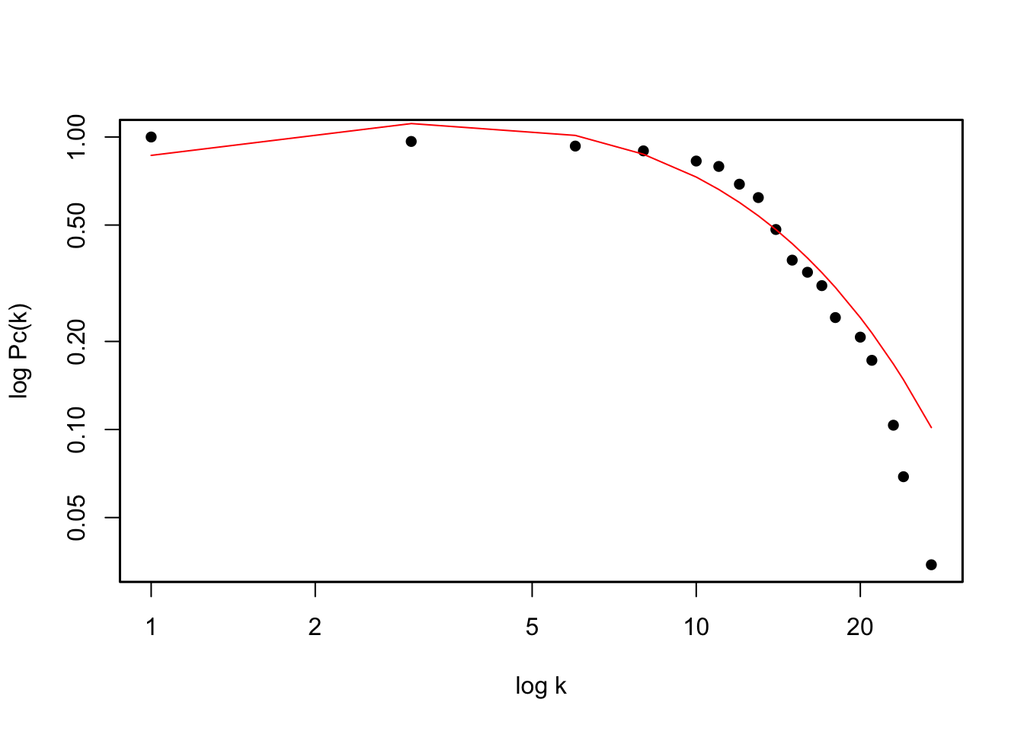

```r
# degrees of the nodes
degs <- degree(benguela.network, mode='all')

occur = as.vector(table(degs))
occur = occur/sum(occur)
p = occur/sum(occur)
y = rev(cumsum(rev(p)))
x = as.numeric(names(table(degs)))

plot(x, y, log="xy", xlab ='log k', ylab='log Pc(k)', type='p', col='black', pch=16)

box(lwd=1.5)

# and we fit a truncated power law to the data
temp <- data.frame(x,y)
mod1 <- nls(y ~ (x^-a*exp(-x/b)), data = temp, start = list(a = 1, b = 1))

# add fitted curve
lines(temp$x, predict(mod1, list(x = temp$x)), col='red')
```

Different centrality measures exist. Here we will focus on **betweenness centrality**, which measures how frequently a node appears on the shortest path between other nodes in the graph. This is a node-level metric that can be used to rank nodes according to their importance in terms of how central they are in the network.

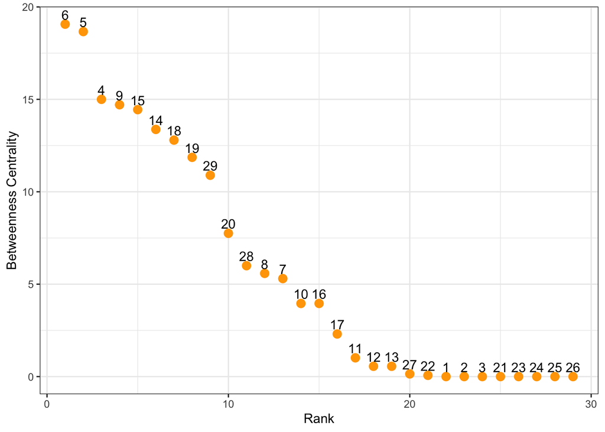

```r
require(ggplot2)
# Betweenness centrality using igraph
between <- igraph::betweenness(benguela.network)

between_df <- data.frame(vertex=as.numeric(V(benguela.network)), between)
between_df <- between_df[order(between_df$between, decreasing = TRUE),]
between_df$rank <- 1:dim(between_df)[1]

ggplot(between_df, aes(rank, between)) + geom_point(colour='orange', size=3) + theme_bw() +
  xlab('Rank') + ylab('Betweenness Centrality') +
  geom_text(aes(label=vertex), vjust=-.5)
```

Clustering coefficient The extent to which neighbours of a node are also connected between them. Clustering coefficient is linked to the idea of **small-world networks**.

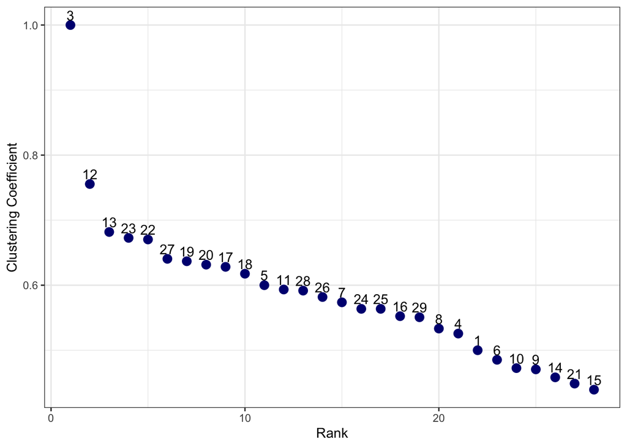

```r
# Clustering Coefficient using igraph
ccs <- igraph::transitivity(benguela.network, type='local')

ccs_df <- data.frame(vertex=as.numeric(V(benguela.network)), ccs)
ccs_df <- ccs_df[-which(is.nan(ccs)),]
ccs_df <- ccs_df[order(ccs_df$ccs, decreasing = TRUE),]
ccs_df$rank <- 1:dim(ccs_df)[1]

ggplot(ccs_df, aes(rank, ccs)) + geom_point(colour='navy', size=3) + theme_bw() +
  xlab('Rank') + ylab('Clustering Coefficient') +
  geom_text(aes(label=vertex), vjust=-.5)
```

### 1.6.8 Modularity

Modularity is a way of quantifying the extent to which a network is organised into subcommunities within which their nodes are more connected amongst themselves than to the rest of the network. It can be quantified using the formula:

$$M = \sum_{s=1}^{N_M} \left[ \frac{l_s}{L} - \left( \frac{d_s}{2L}
\right)^2 \right]$$

where $N_M$ is the number of modules, $L$ is the number of links in the network, $l_s$ is the number of links between nodes in module $s$, and $d_s$ is the sum of the degrees in module $s$. Partitions of nodes into ‘modules’ that yield high scores for $M$ ensure as many within-module links and as few between-module links as possible. Finding partitions that improve the value of $M$ is a hard optimisation problem, and different algorithms have been proposed in the literature to tackle this. An implementation by Guimerà and Nunes Amaral (2005) using simulated annealing yields robust results for this partitioning process. They also define two further metrics associated with the calculation of modularity that can be useful to understand the role of each nodes in the network. These are the within-module degree and the participation coefficient. These measurements provide node-level information on the connectivity profile at the module and network levels respectively. They are defined thus:

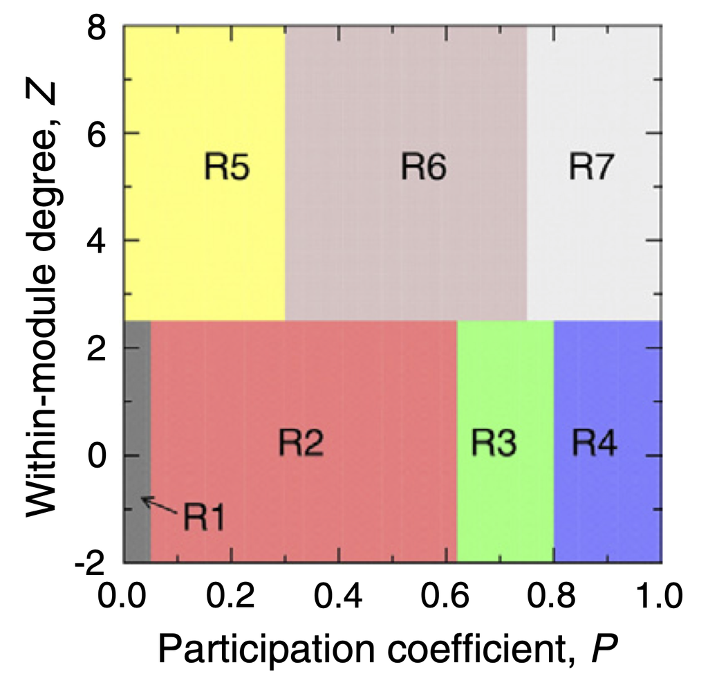

$$z_i = \frac{k_i - \bar{k}_{s_i}}{\sigma_{k_{s_i}}}$$
where $z_i$ is the within-module degree of node $i$, $k_i$ is the number of links to other nodes in its module $s_i$, $k_{s_i}$ is the average degree of all nodes in $s_i$ and $\sigma_{k_{s_i}}$ is the standard deviation of the degree of the nodes within $s_i$.

Participation coefficient, on the other hand, is defined as:

$$P_i = 1 - \sum_{s=1}^{N_M} \left( \frac{k_{is}}{k_i} \right)^2$$

where $k_{is}$ is the number of links of node $i$ to nodes in module $s$ and $k_i$ is the total degree of node $i$.

The P-Z space can be classified into 7 roles that nodes can assume in a network, as proposed by Guimerà and Nunes Amaral (2005), which allow us to characterise nodes according to different profiles from ultra-peripheral (nodes that are only connected within their modules) to kinless hubs (nodes that are very connected to all modules in the network).

```r
require(rnetcarto)
# Calculate modularity using the netcarto algorithm
modularity <- netcarto(benguela.AM)

print(modularity)
```

```
## [[1]]
##    name module connectivity participation             role
## 26   26      0   -0.8944272     0.7107438        Connector
## 10   10      0   -0.8944272     0.7244898        Connector
## 14   14      0   -0.8944272     0.7421875        Connector
## 23   23      0    0.4472136     0.6805556        Connector
## 7     7      0    0.4472136     0.7300000        Connector
## 20   20      0    1.7888544     0.6850000        Connector
## 2     2      1   -2.6347987     0.0000000 Ultra peripheral
## 12   12      1   -0.7342882     0.6600000        Connector
## 21   21      1   -0.2591605     0.6745562        Connector
## 17   17      1   -0.2591605     0.6863905        Connector
## 4     4      1    0.2159671     0.5917160       Peripheral
## 13   13      1    0.2159671     0.5972222       Peripheral
## 22   22      1    0.2159671     0.6428571        Connector
```

[output cut: 19 more lines]

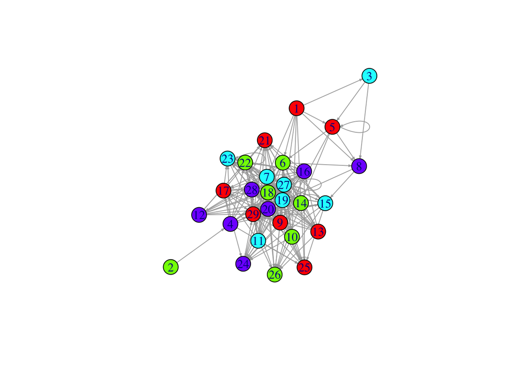

```r
plot(benguela.network, vertex.color=rainbow(4), layout=layout_with_gem, edge.arrow.size = 0.2)
```

### 1.6.9 Nestedness

Nestedness allows us to quantify the extent to which the species composition (or composition interaction partners if thinking of a plant animal interaction network) of less speciose communities (or interacting partners of specialist species in a network) are proper subsets of more diverse communities (or of the set of interacting partners of generalist species if thinking about a bipartite interaction network). This network property can be quantified using the Nestedness metric based on Overlap and Decreasing Fill proposed by Almeida-Neto et al. (2008):

$$NODF = \frac{\sum N_{paired}}{(\frac{n(n-1)}{2})+(\frac{m(m-1)}{2})}$$

where $N_{paired}$ is a score that quantifies the overlap between communities (or diets) of contiguous rows and columns in a community matrix (or incidence matrix for bipartite networks) and $n$ and $m$ are the number of rows and columns in the matrix respectively.

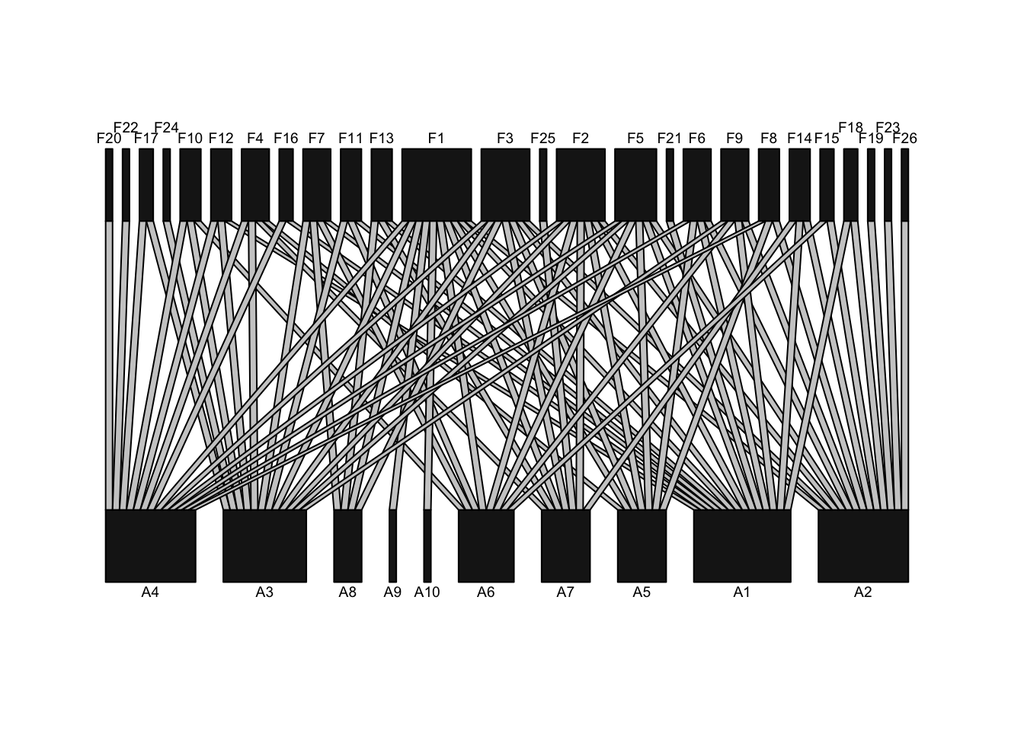

```r
require(bipartite)
# Calculating nestedness using the NODF metric
plotweb(t(anemonef))
```

```r
nested_anemone <- nest.smdm(t(anemonef))

print(nested_anemone)
```

```
## $NODFrow
## [1] 72.40537
##
## $NODFcol
## [1] 53.35897
##
## $NODFmatrix
## [1] 55.67543
```

## References

Almeida-Neto M, Guimaraes P, Guimaraes PR, Loyola RD & Ulrich W (2008) A consistent metric for nestedness analysis in ecological systems: reconciling concept and measurement. *Oikos*, 117, 1227-1239.

Bascompte, J and Jordano P (2007) Plant-animal mutualistic networks: The architecture of biodiversity. *Annual Review of Ecology, Evolution, and Systematics* 38(1), 567-593.

Guimerà R, Amaral LA. Cartography of complex networks: Modules and universal roles. *Journal of Statistical Mechanics*, P02001, 1-13. https://doi.org/10.1088/1742-5468/2005/02/P02001

Montoya, J., Pimm, S. & Solé, R. (2006) Ecological networks and their fragility. *Nature*, 442, 259–264.

Newman, M. E. J. (2003) The Structure and Function of Complex Networks. *SIAM Rev.*, 45(2), 167–256.

Ollerton, J. et al. (2007) Finding NEMO: nestedness engendered by mutualistic organization in anemonefish and their hosts. **Proceedings of the Royal Society B**, 274, 591-598.